# Block 4 playground

```r
library(tidyverse)
```

# mallow data

```r
mallow <- read_csv("https://uoepsy.github.io/data/mallow.csv")
```

## mallow with categ age-group var

```r
mallow <- mallow |>
  mutate(
    agegroup = factor(
      ifelse(age < 6, 'below 6', '6 or older'),
      levels = c('below 6', '6 or older')
    )
  )
```

# week 2: mallow continuous

## intercept-only model

```r
mallow_m0 <- glm(taken ~ 1, data = mallow, family = binomial)
summary(mallow_m0)
```

```
Call:
glm(formula = taken ~ 1, family = binomial, data = mallow)

Coefficients:
            Estimate Std. Error z value Pr(>|z|)
(Intercept) -0.04001    0.20004    -0.2    0.841

(Dispersion parameter for binomial family taken to be 1)

    Null deviance: 138.59  on 99  degrees of freedom
Residual deviance: 138.59  on 99  degrees of freedom
AIC: 140.59

Number of Fisher Scoring iterations: 3
```

```r
confint(mallow_m0)
```

```
     2.5 %     97.5 %
-0.4338547  0.3528137
```

## plot taken ~ age

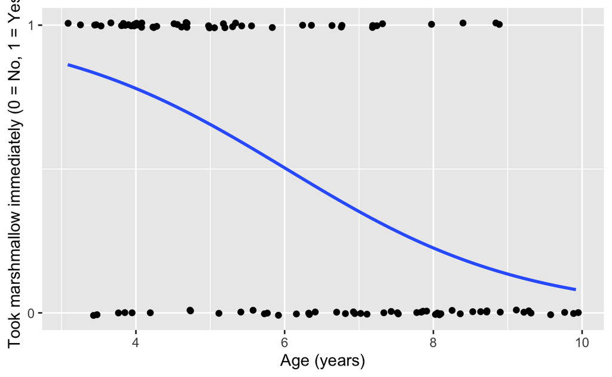

```r
mallow |>
  ggplot(aes(x = age, y = taken)) +

  # wiggle the points around a little bit so they don't all overlap
  geom_jitter(height = 0.01) +

  # label only 0 and 1 on the y axis
  scale_y_continuous(breaks = c(0, 1)) +

  # add curve
  geom_smooth(
    method = "glm",  # not a straight line
    method.args = list(family = binomial),   # specify type of model
    se = FALSE  # remove standard error ribbon around line
  ) +

  labs(
    y = 'Took marshmallow immediately (0 = No, 1 = Yes)',
    x = 'Age (years)'
  )
```

## model taken ~ age

```r
mallow_m1 <- glm(taken ~ age, data = mallow, family = binomial)
summary(mallow_m1)
```

```
Call:
glm(formula = taken ~ age, family = binomial, data = mallow)

Coefficients:
            Estimate Std. Error z value Pr(>|z|)
(Intercept)   3.7642     0.8539   4.408 1.04e-05 ***
age          -0.6247     0.1367  -4.570 4.87e-06 ***
---
Signif. codes:  0 ‘***’ 0.001 ‘**’ 0.01 ‘*’ 0.05 ‘.’ 0.1 ‘ ’ 1

(Dispersion parameter for binomial family taken to be 1)

    Null deviance: 138.59  on 99  degrees of freedom
Residual deviance: 111.21  on 98  degrees of freedom
AIC: 115.21

Number of Fisher Scoring iterations: 4
```

```r
confint(mallow_m1)
```

```
                 2.5 %    97.5 %
(Intercept)  2.1812542  5.553648
age         -0.9123188 -0.372580
```

## plot model-fitted values

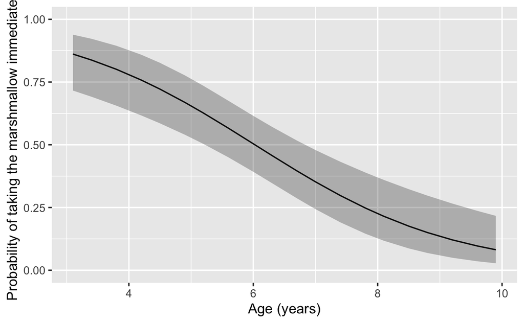

```r
library(effects)

effect(term = "age", mod = mallow_m1, xlevels = 20) |>
  as.data.frame() |>
  ggplot(aes(x = age, y = fit, ymin = lower, ymax = upper))+
  geom_line()+
  geom_ribbon(alpha = .3) +
  labs(
    y = 'Probability of taking the marshmallow immediately',
    x = 'Age (years)'
  ) +
  ylim(0, 1)
```

can we plot it in log-odds space too

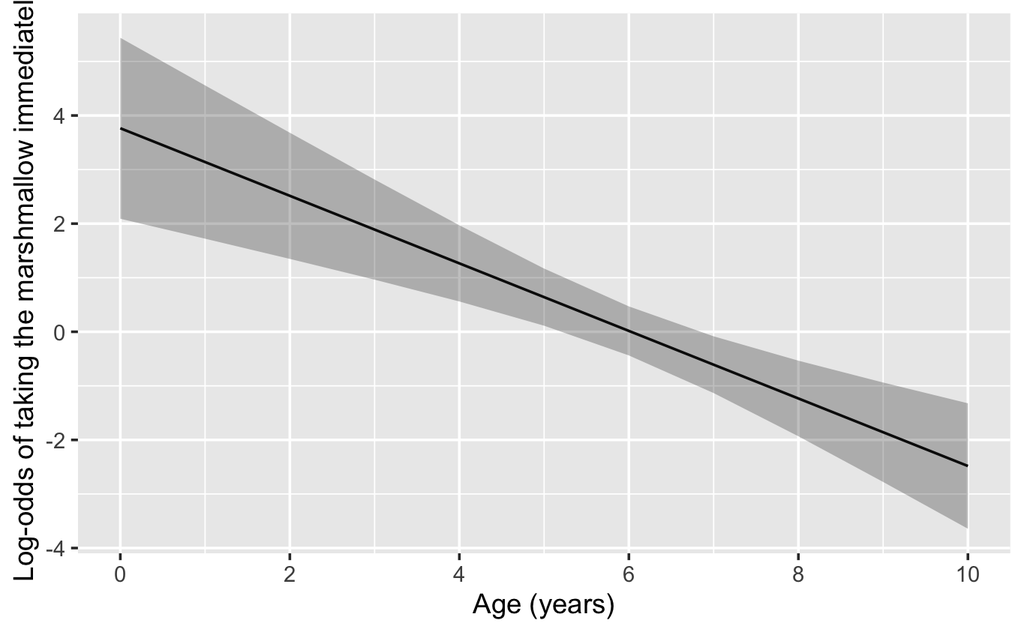

```r
effect(term = "age",  mod = mallow_m1,
       xlevels = list(age = 0:10)) |>
  as.data.frame(type = 'link') |>
  ggplot(aes(x = age, y = fit, ymin = lower, ymax = upper))+
  geom_line()+
  geom_ribbon(alpha = .3) +
  labs(
    y = 'Log-odds of taking the marshmallow immediately',
    x = 'Age (years)'
  ) +
  scale_x_continuous(breaks = seq(0, 10, 2))
```

# week 2: mallow categorical

## plot taken ~ agegroup

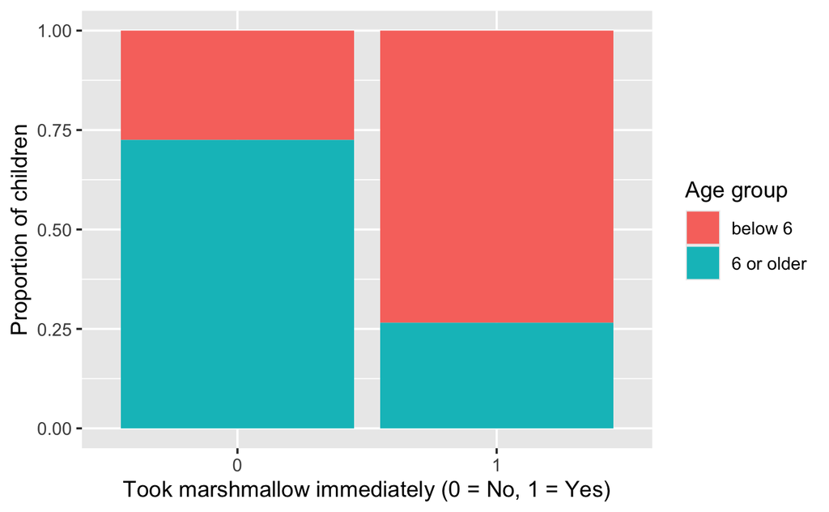

```r
mallow |>
  ggplot(aes(x = factor(taken), fill = agegroup)) +
  geom_bar(position = 'fill') +
  labs(
    y = 'Proportion of children',
    x = 'Took marshmallow immediately (0 = No, 1 = Yes)',
    fill = 'Age group'
  )
```

## model taken ~ agegroup

```r
mallow_m2 <- glm(taken ~ agegroup, data = mallow, family = binomial)
summary(mallow_m2)
```

```
Call:
glm(formula = taken ~ agegroup, family = binomial, data = mallow)

Coefficients:
                   Estimate Std. Error z value Pr(>|z|)
(Intercept)          0.9445     0.3150   2.999  0.00271 **
agegroup6 or older  -1.9904     0.4507  -4.416 1.01e-05 ***
---
Signif. codes:  0 ‘***’ 0.001 ‘**’ 0.01 ‘*’ 0.05 ‘.’ 0.1 ‘ ’ 1

(Dispersion parameter for binomial family taken to be 1)

    Null deviance: 138.59  on 99  degrees of freedom
Residual deviance: 116.60  on 98  degrees of freedom
AIC: 120.6

Number of Fisher Scoring iterations: 4
```

```r
confint(mallow_m2)
```

```
                        2.5 %    97.5 %
(Intercept)         0.3501169  1.595244
agegroup6 or older -2.9078741 -1.133312
```

## plot model-fitted values

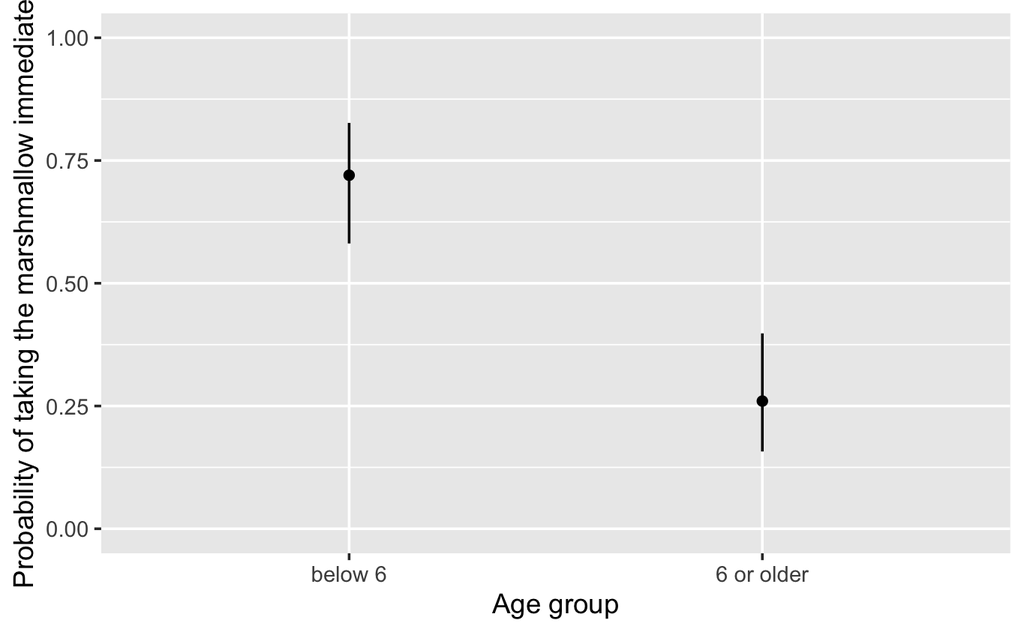

```r
effect(term = 'agegroup', mod = mallow_m2) |>
  as.data.frame() |>
  ggplot(aes(x = agegroup, y = fit)) +
  geom_point() +
  geom_errorbar(aes(ymin = lower, ymax = upper), width = 0) +
  labs(
    y = 'Probability of taking the marshmallow immediately',
    x = 'Age group'
  ) +
  ylim(0, 1)
```

# new week 3 data with an interaction

pro-genAI views as a function of age and culture

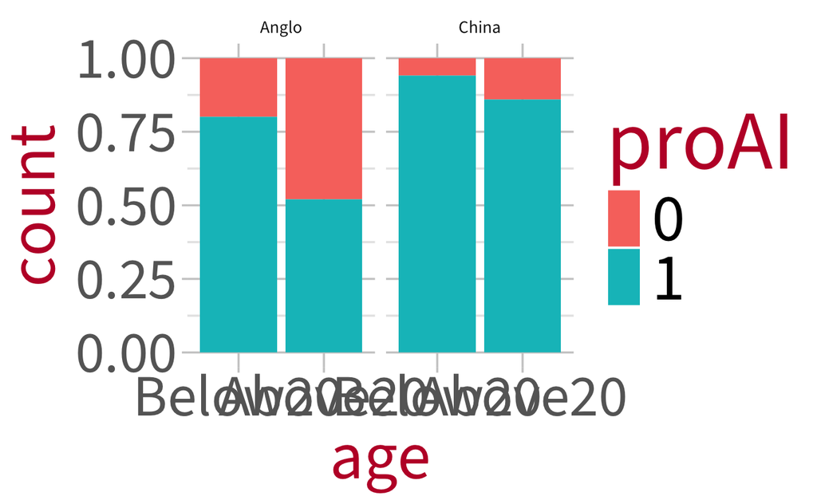

```r
n_obs <- 50

set.seed(1)
proAI_data <- tibble(
  Anglo_Above20 = rnorm(n_obs, mean = qlogis(.50), sd = 1),
  Anglo_Below20 = rnorm(n_obs, mean = qlogis(.65), sd = 1),
  China_Above20 = rnorm(n_obs, mean = qlogis(.80), sd = 1.5),
  China_Below20 = rnorm(n_obs, mean = qlogis(.80), sd = 1),
) |>
  pivot_longer(cols = everything(), names_to = 'splitme', values_to = 'logodds_pro') |>
  separate(splitme, into = c('culture', 'age')) |>
  mutate(
    age = factor(age, levels = c('Below20', 'Above20')),
    prob_pro = plogis(logodds_pro),
    proAI = factor(ifelse(prob_pro > .5, 1, 0))
  )

proAI_data |>
  ggplot(aes(x = age, fill = proAI)) +
  geom_bar(position = 'fill') +
  facet_wrap(~ culture)
```

## model

```r
proAI_mdl <- glm(
  proAI ~ culture * age, data = proAI_data, family = binomial
)
summary(proAI_mdl)
```

```
Call:
glm(formula = proAI ~ culture * age, family = binomial, data = proAI_data)

Coefficients:
                        Estimate Std. Error z value Pr(>|z|)
(Intercept)                1.386      0.354    3.92 0.000088 ***
cultureChina               1.365      0.693    1.97   0.0487 *
ageAbove20                -1.306      0.453   -2.88   0.0039 **
cultureChina:ageAbove20    0.370      0.852    0.43   0.6641
---
Signif. codes:  0 ‘***’ 0.001 ‘**’ 0.01 ‘*’ 0.05 ‘.’ 0.1 ‘ ’ 1

(Dispersion parameter for binomial family taken to be 1)

    Null deviance: 210.76  on 199  degrees of freedom
Residual deviance: 182.47  on 196  degrees of freedom
AIC: 190.5

Number of Fisher Scoring iterations: 5
```

## std dev resids

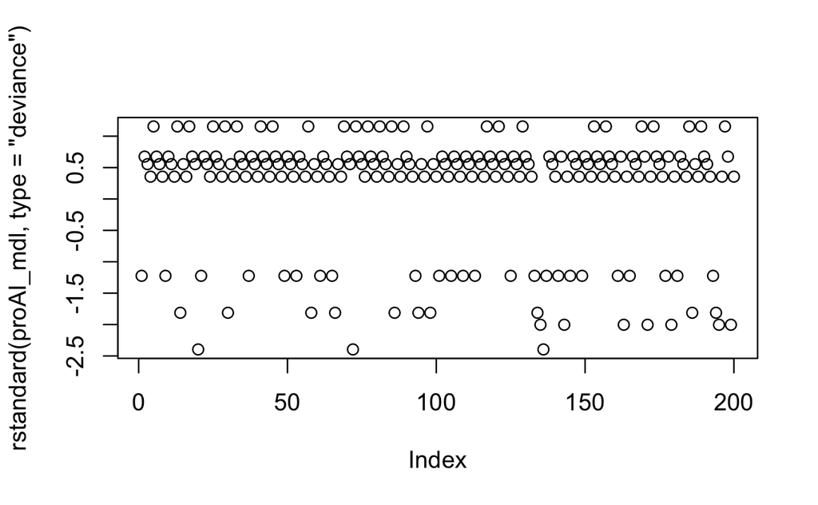

## influential obs

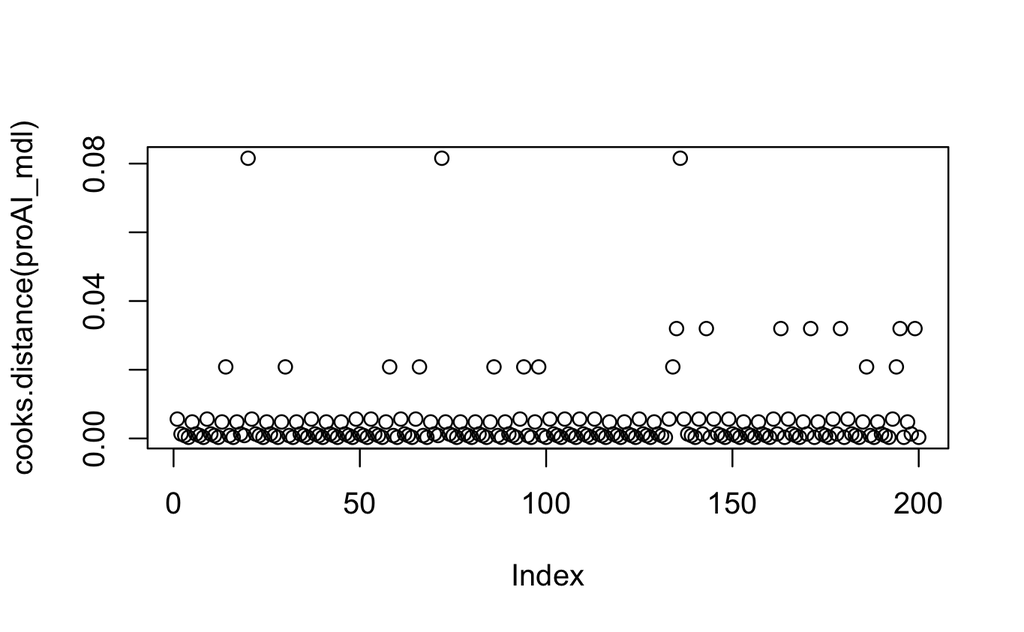

## diff in deviance

```r
anova(proAI_null, proAI_mdl, test = 'Chisq')
```

```
Analysis of Deviance Table

Model 1: proAI ~ 1
Model 2: proAI ~ culture * age
  Resid. Df Resid. Dev Df Deviance  Pr(>Chi)
1       199        211
2       196        182  3     28.3 0.0000031 ***
---
Signif. codes:  0 ‘***’ 0.001 ‘**’ 0.01 ‘*’ 0.05 ‘.’ 0.1 ‘ ’ 1
```

so yes, the diff in dev is significant and the interaction model deviates significantly less from the data comapred to the null model. big whoop?

# week 3: assumptions

## mallow continuous – Assump: check std dev resids

```r
which.max(rstandard(mallow_m1, type = 'deviance'))
which.min(rstandard(mallow_m1, type = 'deviance'))
```

[output not shown]

```r
predict.glm(mallow_m1)[[49]]
```

```
[1] 1.629793
```

```r
mallow[49,]
```

| age | agegroup | taken |
| --- | --- | --- |
| 3.416667 | below 6 | 0 |

```r
predict.glm(mallow_m1)[[78]]
```

```
[1] -1.806099
```

```r
mallow[78,]
```

[output not shown]

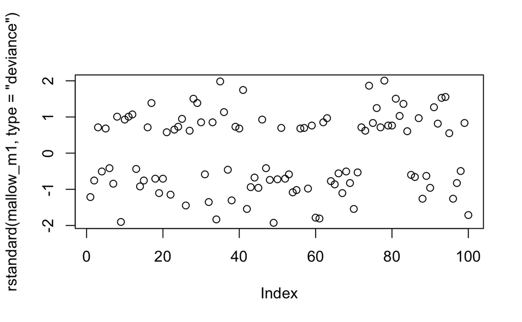

```r
rstandard(mallow_m1, type = 'deviance') |> plot()
```

all good, all within |3|

## mallow categ: check std dev resids

```r
rstandard(mallow_m2, type = 'deviance') |> plot()
```

[output not shown]

# week 3: influential observations

## mallow cont: check Cook’s Distance

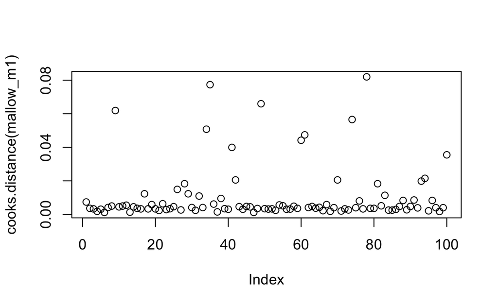

```r
cooks.distance(mallow_m1) |> plot()
```

all good, all below 0.5

## Diag: check Cook’s Distance

```r
cooks.distance(mallow_m2) |> plot()
```

[output not shown]

# week 3: GLM model comparison

## mallow cont – Difference in deviance

```r
anova(mallow_m0, mallow_m1, test = 'Chisq')
```

[output not shown]

## mallow categ – Difference in deviance

```r
anova(mallow_m0, mallow_m2, test = 'Chisq')
```

[output not shown]

# week 3: big-picture modelling strat: when is comparing models a useful thing to do?

from Jo:

> i would phrase it as a “joint test” - if the models differ by 1 df, then the model comparison is equivalent to the test of the slope (for linear, it’s numerically identical, for non-linear models it’s conceptually equivalent), and stress that it’s therefore only useful if you want to test multiple parameters at once.

> B. if you’re actually interested in the influence of a set of predictors that are fairly highly correlated. e.g., i want to know if personality predicts salaries: lm(salary ~ o+c+e+a+n) may well come out with a whole bunch of non-sig coefficients, but a signif F?

> and then have a whole emphasis on DO NOT USE MODEL COMPARISONS TO DECIDE WHAT GOES IN YOUR MODEL

MSMR comment:

> maybe think of model comparisons as being only really useful in reverse, where we start with our ideal model and compare it to a reduced model if that is a useful reference point.

> so the process would be:
> 1. specify the model we want (the one that answers our research q and represents what we believe to be the process that generates the data). this would include the fixed effects required for the question (time*gtype), and the potential confounders (age+prevexp), and the fully maximal random effect structure apportioning variability to different sources.
> 2. simplify the model random effects to obtain convergence. 3 (optional). do a model comparison with a reduced model to assess if the part of the model your interested in (the interaction) is explaining stuff. so here we could compare our model to the same model but without the interaction. and if the thing we’re interested in is just a single coefficient, then this isn’t really necessary as we can just look at that coefficient!